# Exploratory Data Analysis with R by Martin Welss

In this analysis I explore a dataset of white wine. Each observation contains a set of objective, mostly chemical tests and quality variable which is based on sensory data (median of at least 3 evaluations made by wine experts).

First, we load the dataset from the csv-file and get some statistical info about the dataset.

```
##  [1] "X"                    "fixed.acidity"        "volatile.acidity"
##  [4] "citric.acid"          "residual.sugar"       "chlorides"
##  [7] "free.sulfur.dioxide"  "total.sulfur.dioxide" "density"
## [10] "pH"                   "sulphates"            "alcohol"
## [13] "quality"
```

```
## 'data.frame':    4898 obs. of  13 variables:
##  $ X                   : int  1 2 3 4 5 6 7 8 9 10 ...
##  $ fixed.acidity       : num  7 6.3 8.1 7.2 7.2 8.1 6.2 7 6.3 8.1 ...
##  $ volatile.acidity    : num  0.27 0.3 0.28 0.23 0.23 0.28 0.32 0.27 0.3 0.22 ...
##  $ citric.acid         : num  0.36 0.34 0.4 0.32 0.32 0.4 0.16 0.36 0.34 0.43 ...
##  $ residual.sugar      : num  20.7 1.6 6.9 8.5 8.5 6.9 7 20.7 1.6 1.5 ...
##  $ chlorides           : num  0.045 0.049 0.05 0.058 0.058 0.05 0.045 0.045 0.049 0.044 ...
##  $ free.sulfur.dioxide : num  45 14 30 47 47 30 30 45 14 28 ...
##  $ total.sulfur.dioxide: num  170 132 97 186 186 97 136 170 132 129 ...
##  $ density             : num  1.001 0.994 0.995 0.996 0.996 ...
##  $ pH                  : num  3 3.3 3.26 3.19 3.19 3.26 3.18 3 3.3 3.22 ...
##  $ sulphates           : num  0.45 0.49 0.44 0.4 0.4 0.44 0.47 0.45 0.49 0.45 ...
##  $ alcohol             : num  8.8 9.5 10.1 9.9 9.9 10.1 9.6 8.8 9.5 11 ...
##  $ quality             : int  6 6 6 6 6 6 6 6 6 6 ...
```

```
##        X        fixed.acidity    volatile.acidity  citric.acid
##  Min.   :   1   Min.   : 3.800   Min.   :0.0800   Min.   :0.0000
##  1st Qu.:1225   1st Qu.: 6.300   1st Qu.:0.2100   1st Qu.:0.2700
##  Median :2450   Median : 6.800   Median :0.2600   Median :0.3200
##  Mean   :2450   Mean   : 6.855   Mean   :0.2782   Mean   :0.3342
##  3rd Qu.:3674   3rd Qu.: 7.300   3rd Qu.:0.3200   3rd Qu.:0.3900
##  Max.   :4898   Max.   :14.200   Max.   :1.1000   Max.   :1.6600
##  residual.sugar     chlorides       free.sulfur.dioxide
##  Min.   : 0.600   Min.   :0.00900   Min.   :  2.00
##  1st Qu.: 1.700   1st Qu.:0.03600   1st Qu.: 23.00
##  Median : 5.200   Median :0.04300   Median : 34.00
##  Mean   : 6.391   Mean   :0.04577   Mean   : 35.31
##  3rd Qu.: 9.900   3rd Qu.:0.05000   3rd Qu.: 46.00
##  Max.   :65.800   Max.   :0.34600   Max.   :289.00
##  total.sulfur.dioxide    density             pH          sulphates
##  Min.   :  9.0        Min.   :0.9871   Min.   :2.720   Min.   :0.2200
##  1st Qu.:108.0        1st Qu.:0.9917   1st Qu.:3.090   1st Qu.:0.4100
##  Median :134.0        Median :0.9937   Median :3.180   Median :0.4700
##  Mean   :138.4        Mean   :0.9940   Mean   :3.188   Mean   :0.4898
##  3rd Qu.:167.0        3rd Qu.:0.9961   3rd Qu.:3.280   3rd Qu.:0.5500
##  Max.   :440.0        Max.   :1.0390   Max.   :3.820   Max.   :1.0800
##     alcohol         quality
##  Min.   : 8.00   Min.   :3.000
##  1st Qu.: 9.50   1st Qu.:5.000
##  Median :10.40   Median :6.000
##  Mean   :10.51   Mean   :5.878
##  3rd Qu.:11.40   3rd Qu.:6.000
##  Max.   :14.20   Max.   :9.000
```

# Univariate Plots Section

Quality is of course of primary interest because it is the variable we want to predict from the others, so we look at its histogram first.

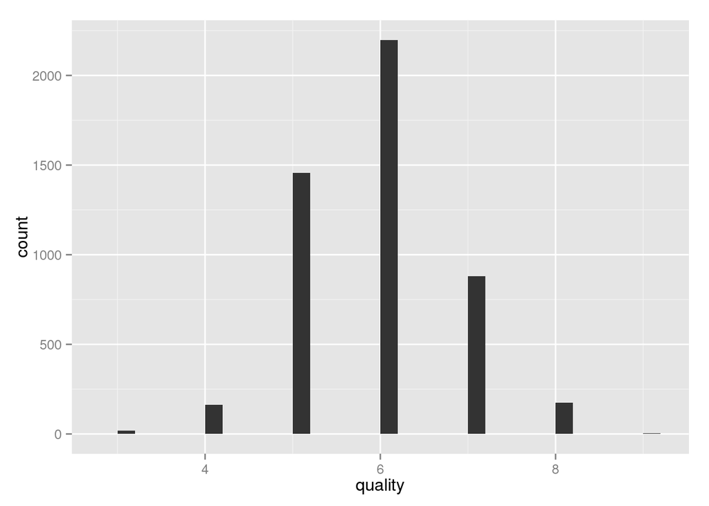

We see that the quality is close to a normal distribution which is not fully symmetric because the value for quality 5 is higher than the corresponding value 7. Given that the quality ranges from 1 to 10, we see the maximum at 6, which is sightly above full mediocrity.

Now the histograms of the potential “input” variables:

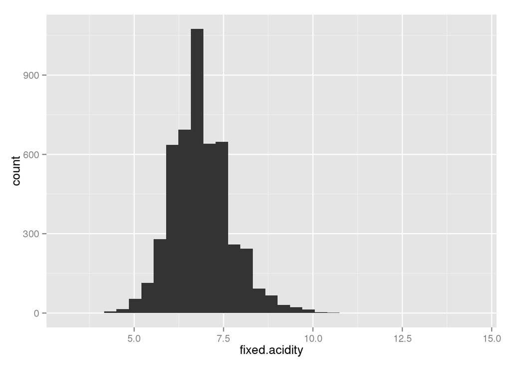

Nothing special about the histogram for fixed acidity: it resembles a normal distribution with no gaps and the values are in the range between 4 and 11.

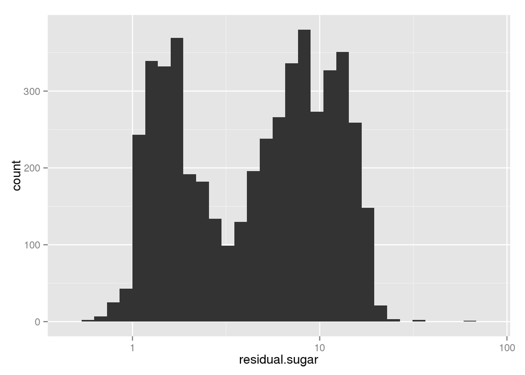

The histogram on residual sugar has some interesting features:

- I scaled the x-axis by log10 to have a tighter view
- from left to right it has a peak, then a low and then two peaks
- all three peaks are about the same height
- it does not resemble any standard distribution I know

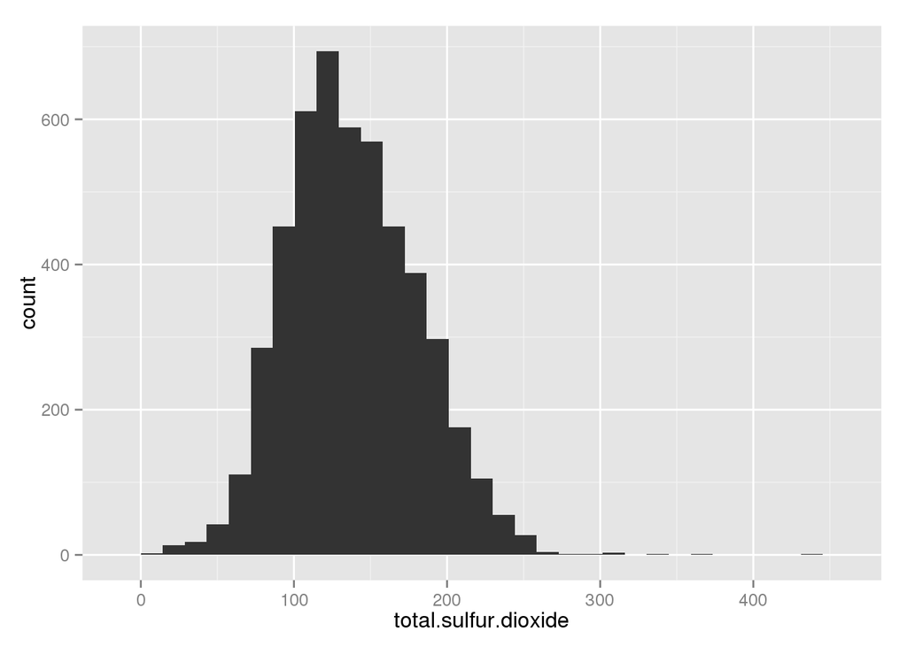

The histogram for total sulfur dioxide looks again like a normal distribution, but other than fixed acidity the values have a much greater spectrum and range from 0 to over 300 with some outliers well over 400.

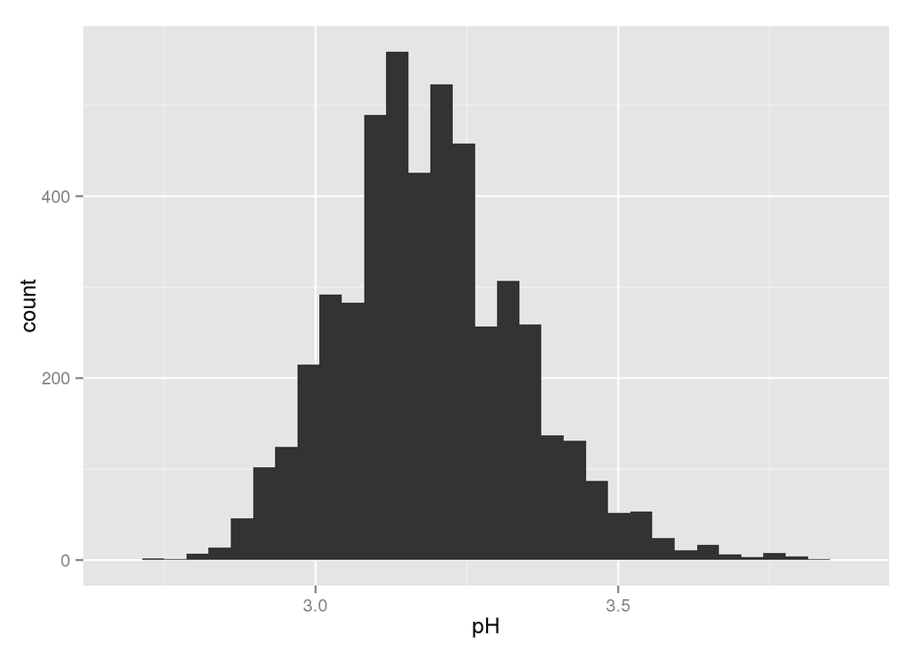

The value range for pH is pretty narrow with most of the values between 3 and 3.5, so all values are chemically well in the acidity range and not alkaline (which is above 7). The distribution resembles a normal distribution with an unusual double peak.

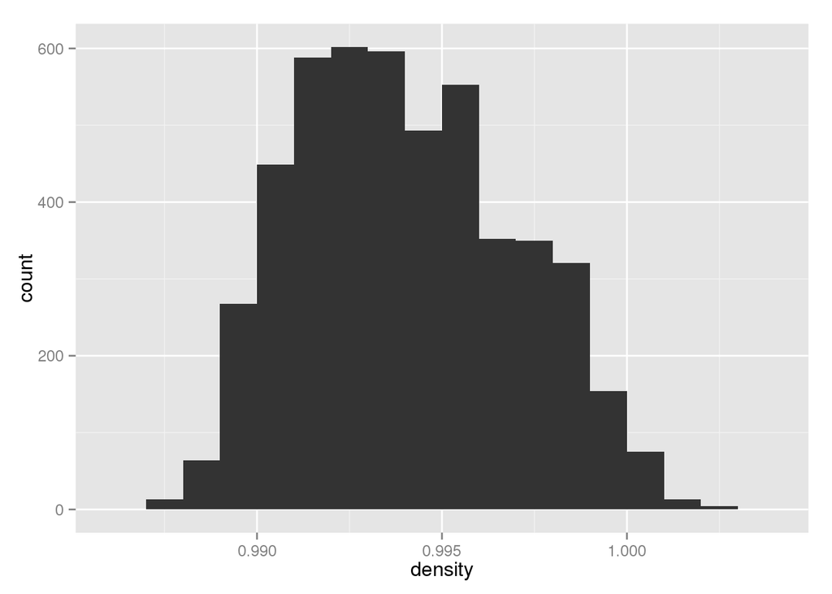

Interesting about the density plot is the narrow value range with most of them in the interval between 0.9 and 1.0. The distribution looks like a slightly asymmetrical normal distribution.

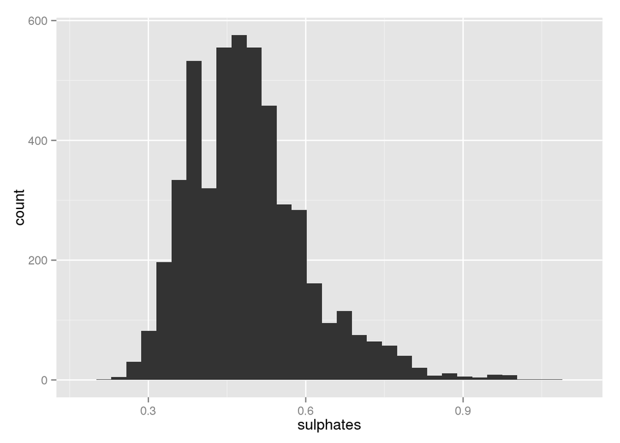

The sulphates distribution has a small tail on the right and a low left of the peak.

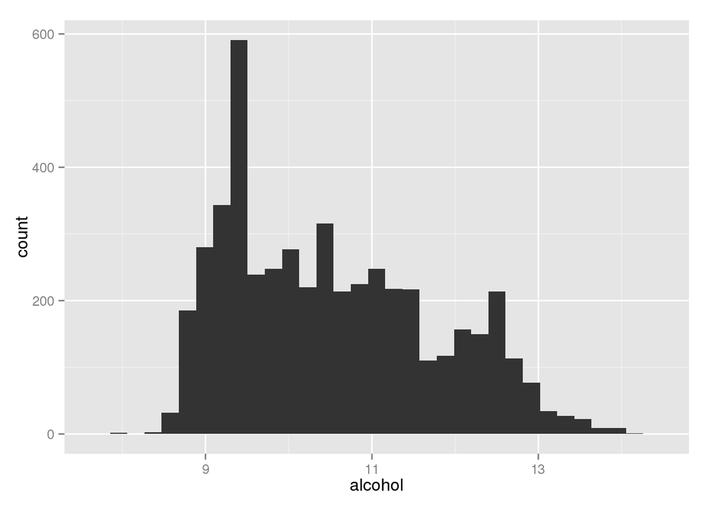

The alcohol distribution looks interesting because it is asymmetric and starts with a peak count at about 600 on the left and falls sharply down to 200 and then slowly descents to zero with little ups and downs.

I think we can get a better impression of the quality distribution with frequency polygons:

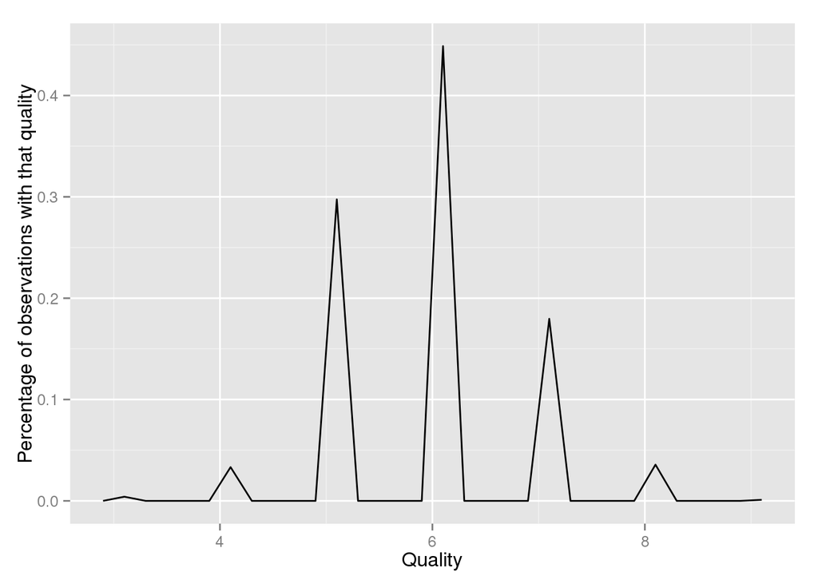

Here the frequency polygons confirm the resemblance of a normal distribution.

The distributions of alcohol and quality resemble slightly so alcohol seems to be the best lead. We transform it to be a factor and remove the observations where alcohol.bucket is NA to get cleaner plots. I want to get a more detailed impression of alcohol.bucket, so I plot a histogram and a boxplot.

```r
wine$alcohol.bucket <- cut(wine$alcohol, c(8,9,10,11,12,13,14))

wine <- subset(wine, !is.na(wine$alcohol.bucket))
```

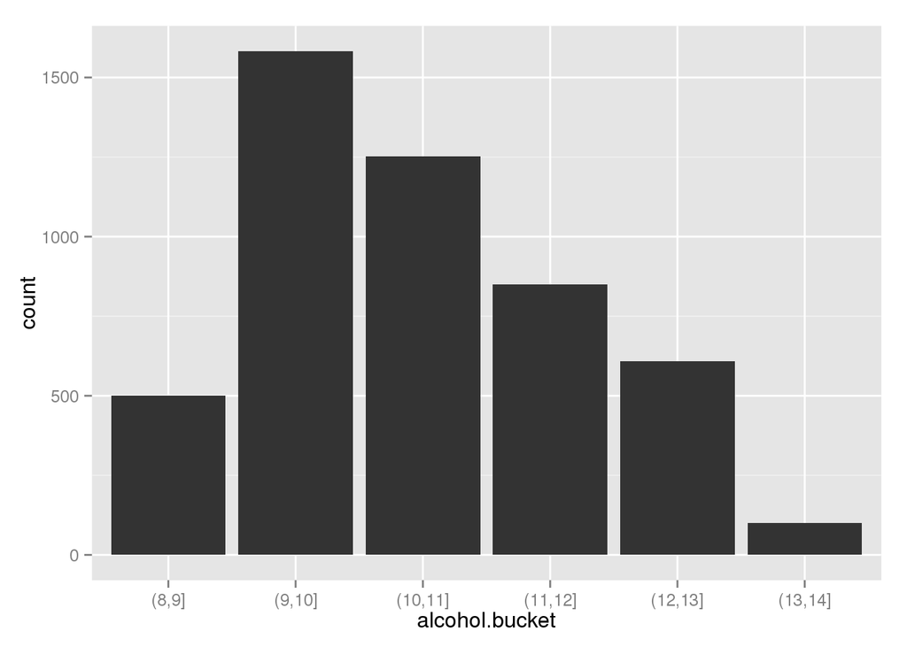

The alcohol bucket histogram underlines the asymmetric outline of the distribution with the peak already at interval (9,10] and the decreasing continuously to interval (13,14]

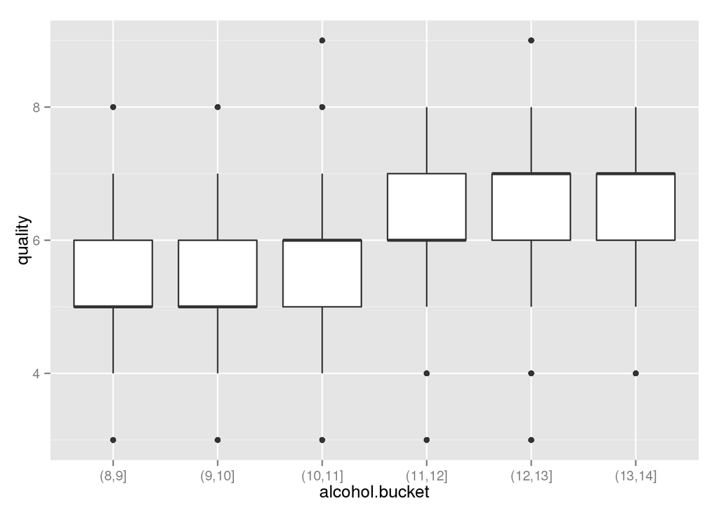

The boxplot is the first highlight showing a clear relation between alcohol and quality with quality continuously increasing along with the level of alcohol.

# Univariate Analysis

### What is the structure of your dataset?

It’s a tidy dataset where each variable is a column and each observation is a row. In this case, the dataset on white wines has 4898 observations of 13 variables.

### What is/are the main feature(s) of interest in your dataset?

The main feature of interest in the dataset is quality and how to predict it from the other variables.

### What other features in the dataset do you think will help support your investigation into your feature(s) of interest?

From the plots we see that the quality resembles a normal distribution. So we need to check the correlation between quality and the other variables. From the alcohol-quality boxplot we can see a trend that Quality increases with more alcohol, but the correlation does not convince me yet, this needs more investigation in the following sections.

### Did you create any new variables from existing variables in the dataset?

Yes, I created alcohol.bucket variable to get a feeling for the distributions of quality by alcohol and created also a corresponding boxplot.

### Of the features you investigated, were there any unusual distributions? Did you perform any operations on the data to tidy, adjust, or change the form of the data? If so, why did you do this?

The residual.sugar has a quite asymmetric distribution, the pH variable’s distribution has two peaks. Other than adding the alcohol.bucket variable, I needed the alcohol.bucket variable to create a boxplot of quality by alcohol and removed the records where alcohol.bucket was NA.

# Bivariate Plots Section

To start, let’s create some scatterplots to find interesting correlations…

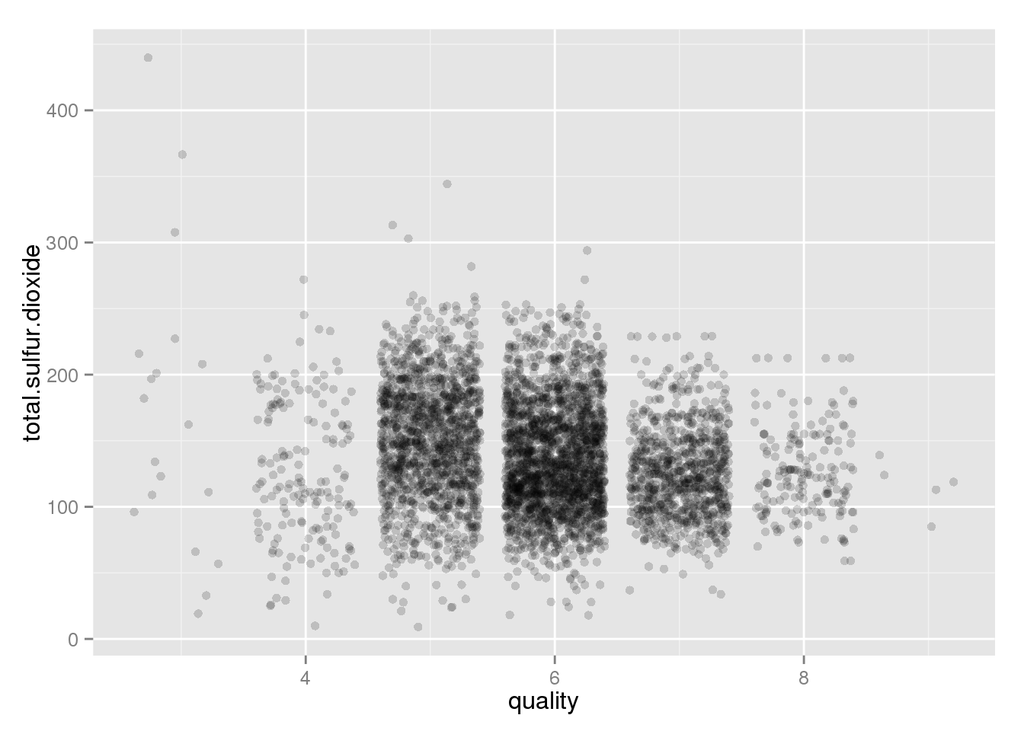

I had to apply jitter and alpha to cope with overplotting, but there is no clear relation between total sulfur dioxide and quality.

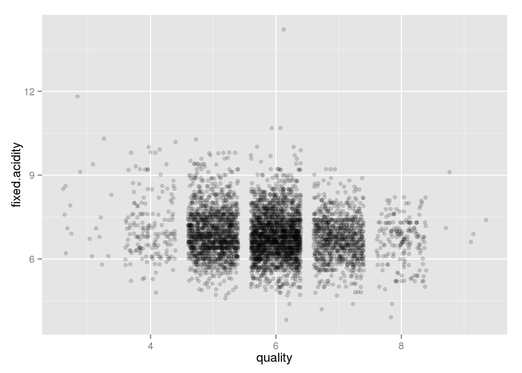

No clear trend either between fixed acidity and quality.

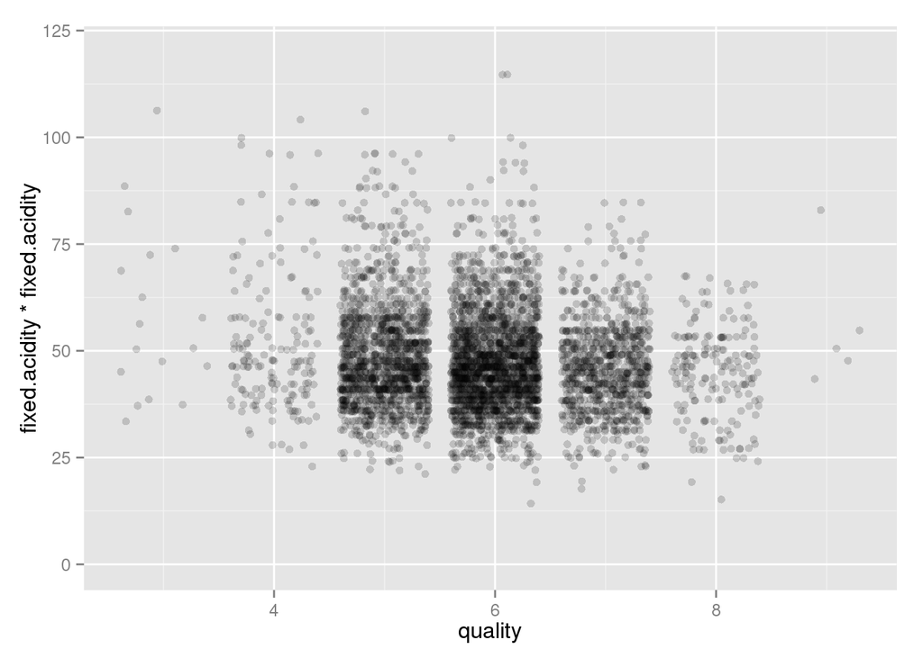

No winner so far, maybe a linear model layer helps

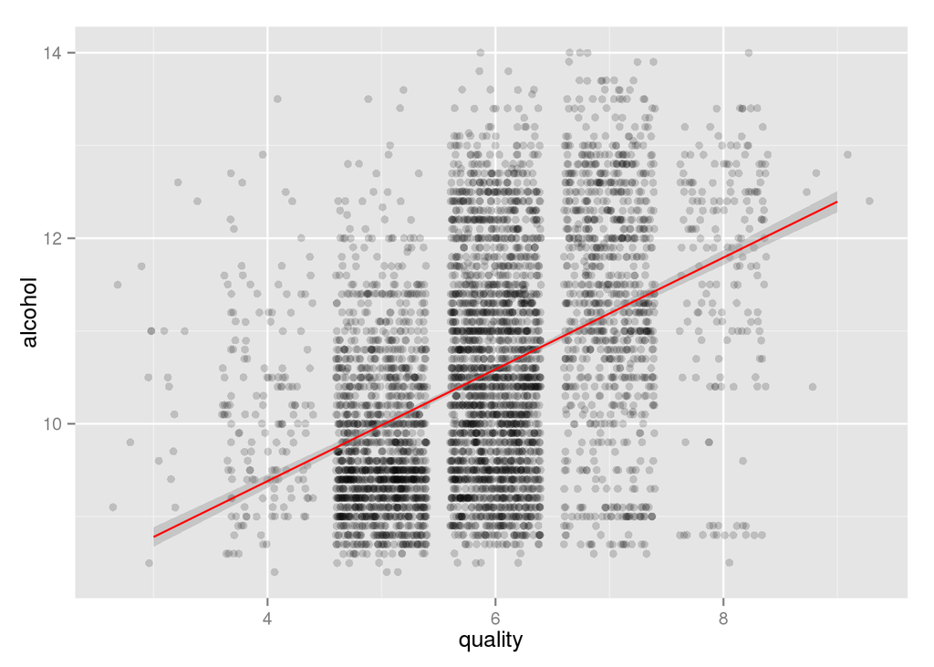

```r
ggplot(aes(x=quality, y=alcohol), data=wine) +
  geom_jitter(alpha=1/6) +
  geom_smooth(method='lm', color='red')
```

Well, that looks promising let’s keep the pair alcohol and quality in mind. We can see clearly that quality increases with higher levels of alcohol.

Are there correlations of higher order? Let’s try transformed variables.

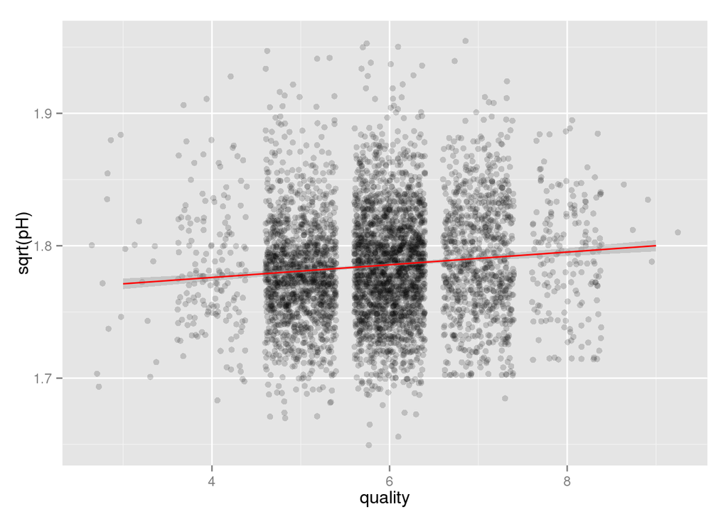

Nothing of interest between sqrt(pH) and quality, the line is almost flat.

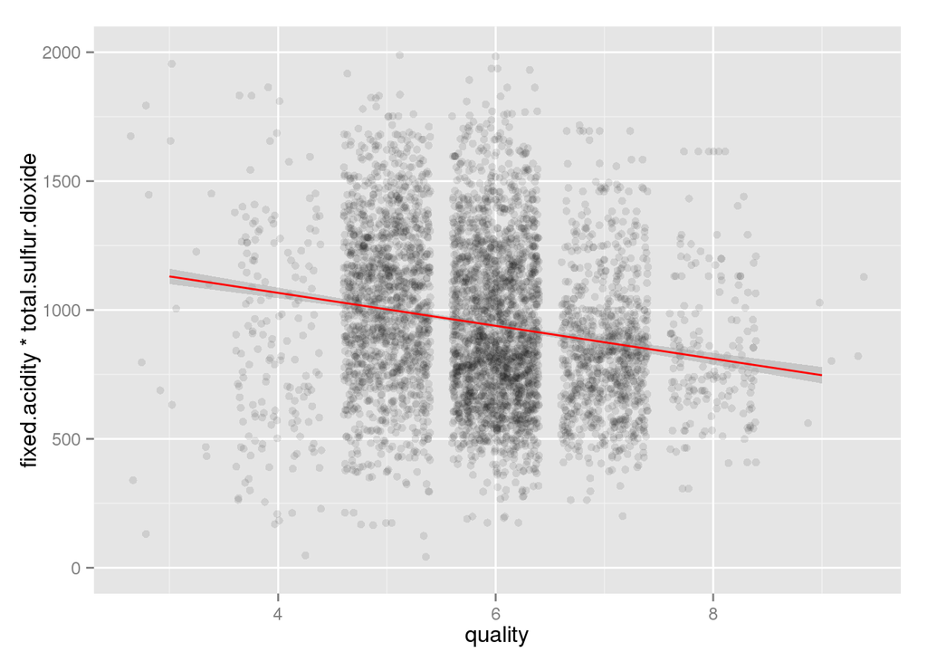

The smoother line for quality by the product of fixed acidity and total sulfur dioxide shows a little slope, but it is far from a convincing correlation. We should nevertheless keep it in mind.

I create a new variable prop.acidity to combine acidity-types and plot it.

```r
wine$prop.acidity <- wine$fixed.acidity / wine$volatile.acidity
```

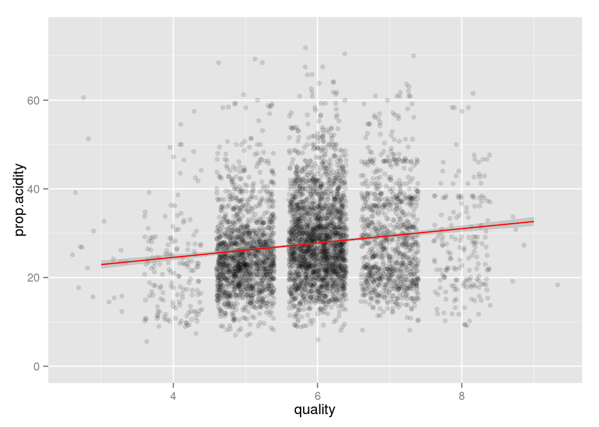

What about correlations between the other variables?

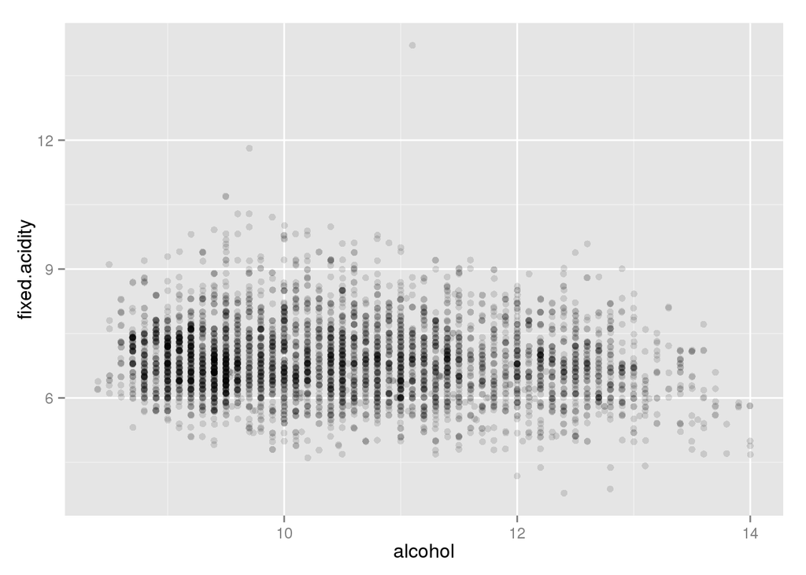

We see the values for fixed acidity stay in a range between 5 and 11 with more datapoints in the area of lower alcohol. No correlation to see here.

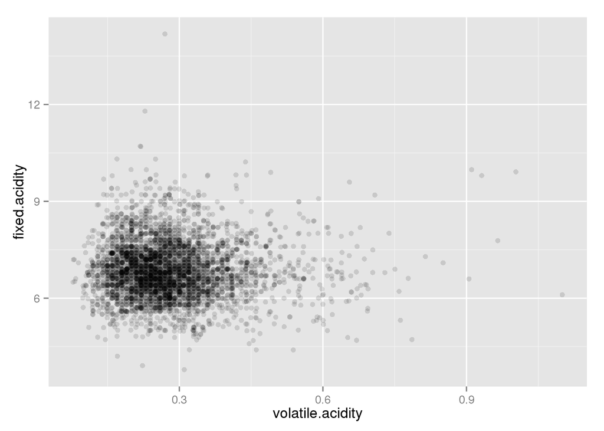

The scatterplot of the two acidities yields the shape of an egg in the left lower quadrant of the plot.

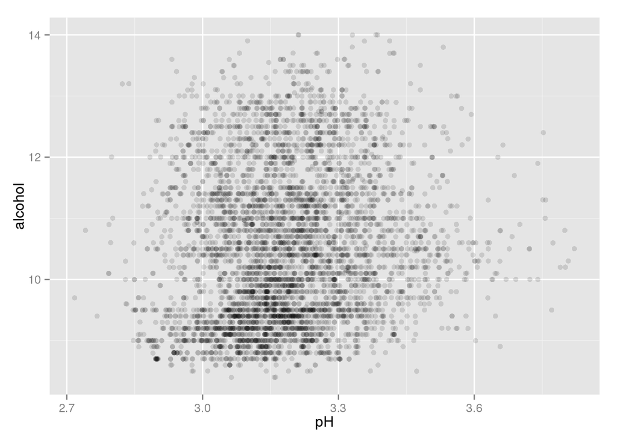

The scatterplot of alcohol and pH results in quite equally distributed points which shows no correlation at all.The plot is a little more dense for alcohol values below 10.

We should at least here see a correlation between pH and acidity because of the chemical definition of pH.

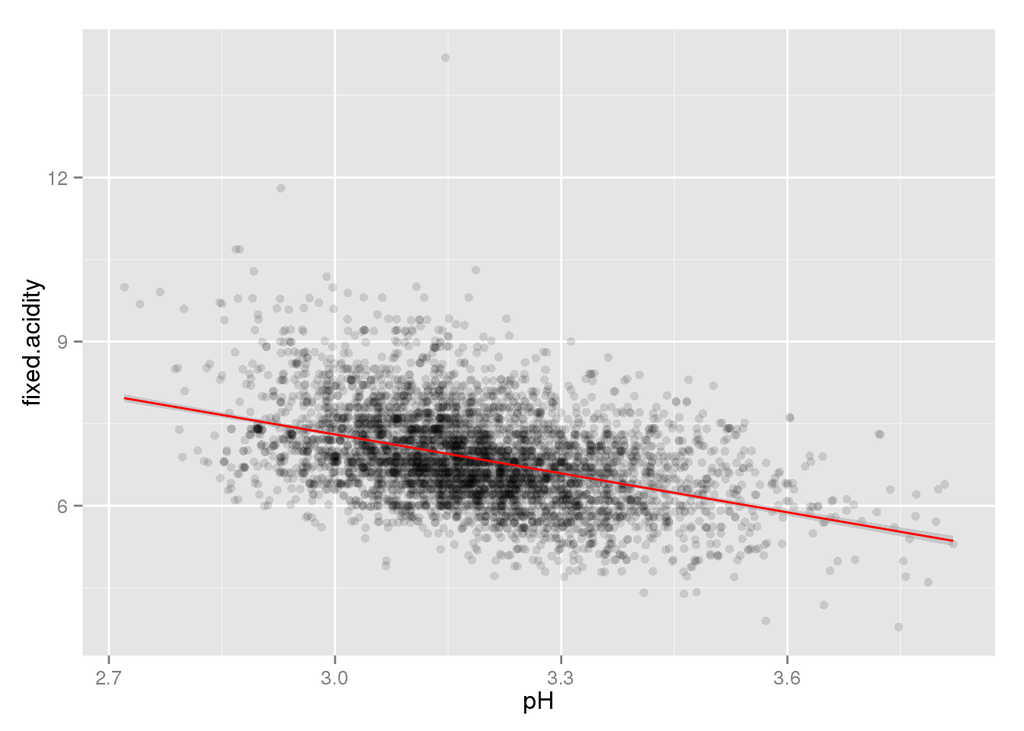

We don’t get disappointed as we see that fixed acidity decreases with higher pH values but that does not help for the prediction of quality.

# Bivariate Analysis

### Talk about some of the relationships you observed in this part of the investigation. How did the feature(s) of interest vary with other features in the dataset?

Since we want to find the correlations between quality and the rest of the variables, I created some scatterplots and tested the correlation between promising quality-variable combinations. I had to deal with overplotting by adding transparency to the points. I carefully selected the alpha value so that the points of high quality observations are still visible. Furthermore I added in some plots a geom_smooth layer based on a linear model to see the correlation more clearly.

Because I could not find any convincing relation, I tried transformations of variables like the square fixed.acidity, the square root of pH and introduced a new variable prop.acidity followed by corresponding plots. But still no strong correlation could be found.

So I decided to test the some correlations numerically, but there is none greater than 0.5, which would have been a breakthrough.

```r
cor.test(wine$quality, wine$alcohol)
```

```
##
##  Pearson's product-moment correlation
##
## data:  wine$quality and wine$alcohol
## t = 33.701, df = 4892, p-value < 2.2e-16
## alternative hypothesis: true correlation is not equal to 0
## 95 percent confidence interval:
##  0.4110562 0.4565404
## sample estimates:
##       cor
## 0.4340749
```

```r
cor.test(wine$quality, wine$total.sulfur.dioxide)
```

```
##
##  Pearson's product-moment correlation
##
## data:  wine$quality and wine$total.sulfur.dioxide
## t = -12.3785, df = 4892, p-value < 2.2e-16
## alternative hypothesis: true correlation is not equal to 0
## 95 percent confidence interval:
##  -0.2013076 -0.1469723
## sample estimates:
##        cor
## -0.1742726
```

```r
cor.test(wine$quality, wine$fixed.acidity)
```

```
##
##  Pearson's product-moment correlation
##
## data:  wine$quality and wine$fixed.acidity
## t = -8.1871, df = 4892, p-value = 3.383e-16
## alternative hypothesis: true correlation is not equal to 0
## 95 percent confidence interval:
##  -0.14380966 -0.08853068
## sample estimates:
##        cor
## -0.1162602
```

```r
cor.test(wine$quality, wine$prop.acidity)
```

```
##
##  Pearson's product-moment correlation
##
## data:  wine$quality and wine$prop.acidity
## t = 10.2202, df = 4892, p-value < 2.2e-16
## alternative hypothesis: true correlation is not equal to 0
## 95 percent confidence interval:
##  0.1170433 0.1719085
## sample estimates:
##      cor
## 0.144587
```

### Did you observe any interesting relationships between the other features (not the main feature(s) of interest)?

I found a slight linear relationship between pH and fixed.acidity where the fixed acidity decreases with increasing pH values.

# Multivariate Plots Section

We start with the strongest lead alcohol and quality but this time faceted by the different levels of alcohol using the alcohol.bucket variable.

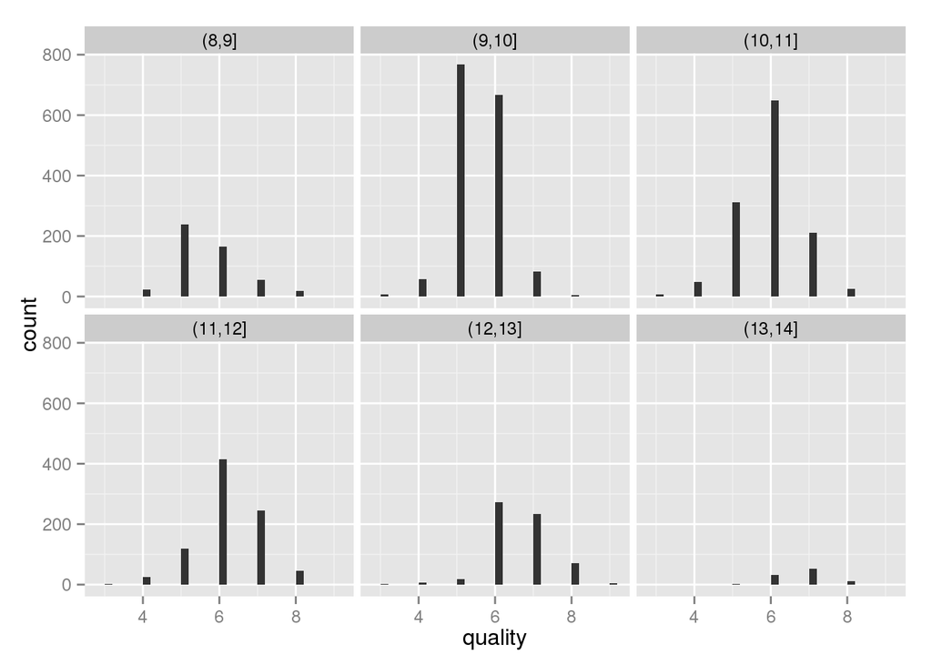

The subplots show clearly how different the counts are regarding the alcohol levels: there are only a few (less than 100) datapoints for the highest alcohol level of 13 whereas for the levels of 9 and 10 there are more than 1500 datapoints. But plot also confirms the correlation between alcohol and quality as we see the bars wander to the right towards better quality with higher alcohol levels.

I think I need quality to be a factor, so create it

```r
wine$quality.factor <- factor(wine$quality)
```

I use jitter to get a better color impression.

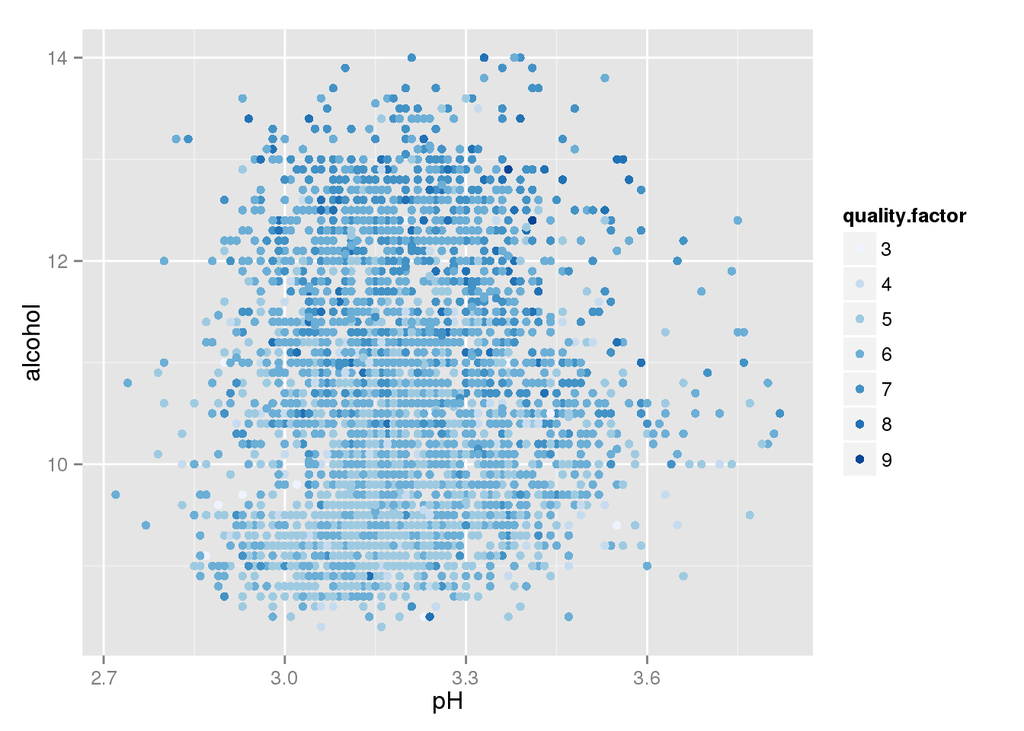

We see here again that the darker points of better quality correspond with higher alcohol levels, but pH is equally distributed among quality. pH seems to be a dead end, let’s try other variables.

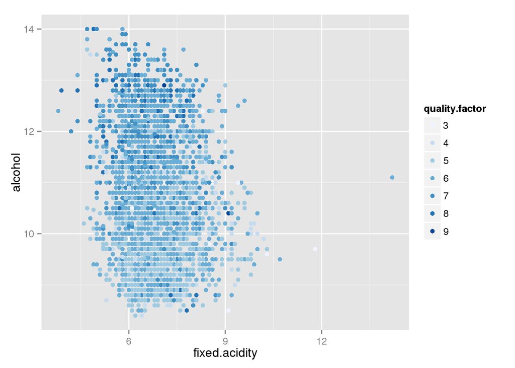

Same conclusion with fixed acidity: the alcohol-quality relation shows again, but fixed acidity has no influence.

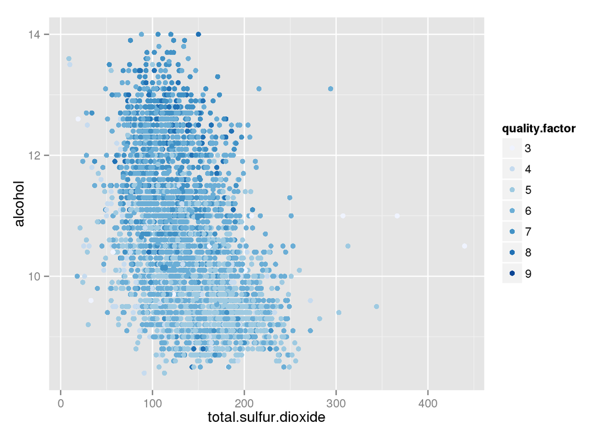

The plot with total sulfur dioxide finally shows a very small interesting deformation where the lighter of low quality datapoints are shifted to the lower right. We should keep that in mind.

We compute a new variable of promising candidates and create a corresponding plot.

```r
wine$qmix <- wine$alcohol*
  wine$total.sulfur.dioxide *
  wine$fixed.acidity
```

The new qmix variable is quite uniformly distributed around the center of the plot, so no new revelations here.

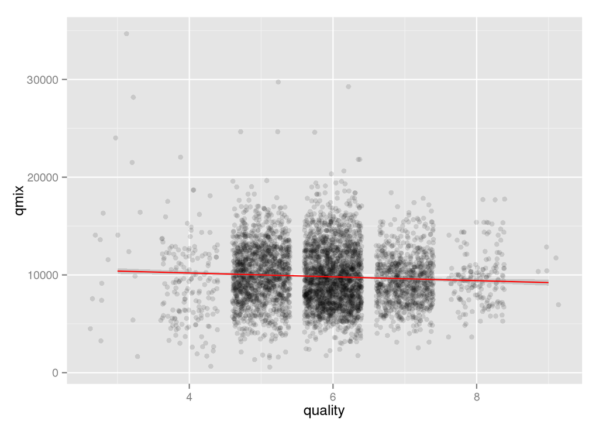

Finally we test the correlation, but still not better than alcohol.

```r
cor.test(wine$quality, wine$qmix)
```

```
##
##  Pearson's product-moment correlation
##
## data:  wine$quality and wine$qmix
## t = -3.9809, df = 4892, p-value = 6.964e-05
## alternative hypothesis: true correlation is not equal to 0
## 95 percent confidence interval:
##  -0.08470795 -0.02885295
## sample estimates:
##         cor
## -0.05682492
```

# Multivariate Analysis

### Talk about some of the relationships you observed in this part of the investigation. Were there features that strengthened each other in terms of looking at your feature(s) of interest?

To get a better impression of the relationship between quality and the other variables, I needed quality to be a factor. So I created a new factor variable from quality and used in the scatterplots to color the points. Overplotting was again to be dealt with and again I selected the alpha value so that the colors of the high and low quality observations stay visible. But there was no match winner revealed. I than created a new variable that was the product of three other variables that so far showed at least a little correlation with quality:

- alcohol
- total.sulfur.dioxide
- fixed.acidity

The plot did not show a strong correlation, which was supported by the calculation of the correlation coefficient.

### Were there any interesting or surprising interactions between features?

What I found interesting was the relation between alcohol and quality over several other variables like pH or fixed acidity.The relation between alcohol and quality seems to be independent from the other variables since the higher quality points stay in the upper area of the plot. This supports a constant correlation between alcohol and quality.

# Final Plots and Summary

### Plot One

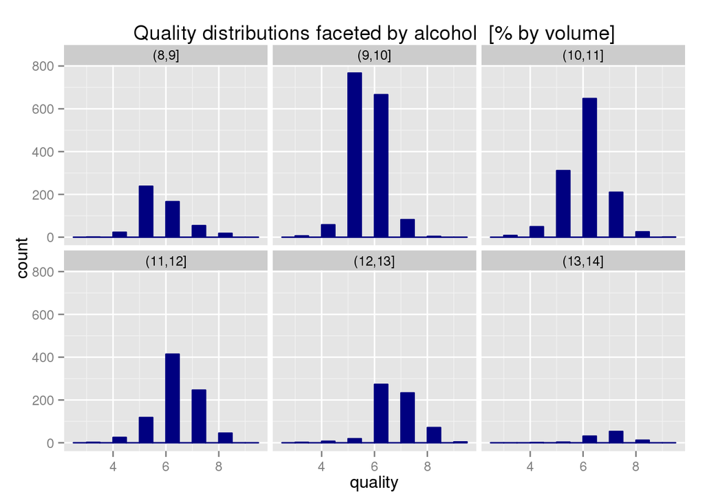

### Description One

Sine quality is the output variable that we try to predict from the other variables, I present as first plot the quality distribution faceted by alcohol, which so far has the strongest correlation with quality. We see that the first two subplots with the low levels of alcohol have their maximum at quality 5 whereas the following plots, the maximum moves to higher quality levels. I think this plot is important and quite interesting, because it gives a good impression of the relation between the quality and alcohol which is its strongest correlation. Very few wines have excellent quality and so have only a few wines a bad quality.

### Plot Two

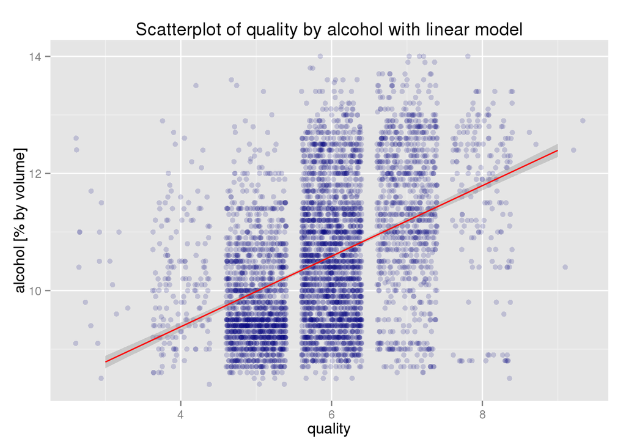

### Description Two

The second plot is a scatterplot which shows clearly a linear correlation between quality and alcohol with the red line depicting the correlation. This supports the assumption that higher levels of alcohol correspond with higher quality. The plot also shows that the vast majority of vines have mediocre quality and only very few have the top level quality of 9 or a bad quality below 4.

### Plot Three

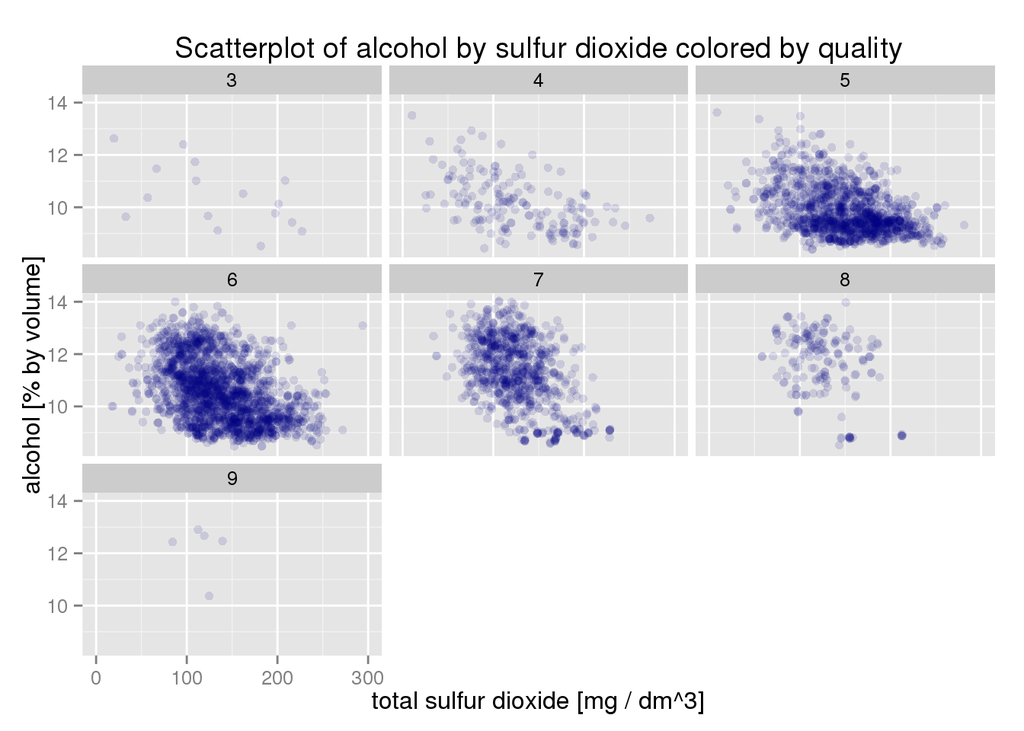

### Description Three

Plot three finally shows a scatterplot of alcohol by total sulfur dioxide faceted by quality. I chose these three variables because they reflect the key characteristics of my analysis:

1. alcohol and quality correlate
2. total sulfur dioxide and quality correlate
3. the subplots by quality support that

We see over the subplots from 3 (poor quality) to 9 (best quality) how the datapoints climb to higher alcohol levels between 10 and 12 % and a sulfur level condenses between 50 and 150 mg/dm³. We see also that most wines have a medium quality of 5 or 6.

# Reflection

I started off with histograms of the variables to get an overview of the distributions. Alcohol seemed most promising, so I wanted to create a boxplot. For that I needed alcohol to be a factor variable, so I used the cut function to create the alcohol.bucket variable. The boxplot then supported the relationship between alcohol and quality.

The bivariate analysis was somewhat sobering because no strong correlation could be found.To avoid overseeing a correlation I added to some of the plots a linear model smoother but no correlation was stronger than between alcohol and quality. Some slight correlation was found between sulfur dioxide, acidity and pH on the one hand and quality on the other hand. I created a new variable and tried transformations and combinations of the input variables.

The trend continued in the multivariate analysis.First I needed quality to be a factor, so I created a new variable for that. Then I used this factor variable to color some of the scatter plots. I finally created another variable the was the multiplication of alcohol, total.sulfur.dioxide and fixed.acidity. But no strong correlation surfaced.

## Conclusion

If I were a winemaker, I would probably be more interested in the relationship of the vintage and the quality *before* I start the wine press.